# スパース回帰分析とパターン認識

後藤太郎

2023-11-16

## 第2章 統計手法によるパターン認識（2.4章）

### 多群の場合のベイズ判別

- 3群の判別分析  
  判別関数（線形/2次形式）は2群の場合と同じ  
  ${f_3(x)}$をベースラインと考えて、$\frac{f_1(x)}{f_3(x)}$と$\frac{f_2(x)}{f_3(x)}$の尤度比を算出、尤度比が1を超えていれば$g_1$もしくは$g_2$と判別（尤度比の大きい方に群判別）、超えなければ$g_3$と判別する  
  群別の事前確率は各群の事前確率を$\pi_k$として設定する  
  $\pi_k>0, \quad k=1,2,\cdots,g \quad \sum\limits_{k=1}^{g}\pi_k=1$

### 3群のLDAの実行

- 教科書の事例（wineデータ）  
  教科書p78の事例を行う（codeは適宜書き直した）
- 分析用のpackageを設定

```r
pkgs <- c("ggplot2", "skimr", "cowplot", "gridExtra")

for(i in seq_along(pkgs)) {
    if(!require(pkgs[[i]], character.only = TRUE)){
        install.packages(pkgs[[i]], dependencies = TRUE)
        library(pkgs[[i]], character.only = TRUE)
    }
}
```

- wineデータの取得と確認

```r
# UCI ML database からデータを取得
url <- "http://archive.ics.uci.edu/ml/machine-learning-databases/wine/wine.data"
Wine <- read.csv(url, header = FALSE)

# 変数名を設定
col_nm <- c(
    "class",
    "alcohol",
    "malic_acid",
    "ash",
    "alcalinity_of_ash",
    "magnesium",
    "total_phenols",
    "flavanoids",
    "nonflavanoid_phenols",
    "proanthocyanins",
    "color_intensity",
    "hue",
    "od280/od315_of_diluted_wines",
    "proline"
)
colnames(Wine) <- col_nm

# データの確認（実際の分析は変数を絞って行う）
Wine
```

| class | alcohol | malic_acid | ash | alcalinity_of_ash | magnesium | total_phenols | flavanoids | nonflavanoid_phenols | proanthocyanins | color_intensity | hue | od280/od315_of_diluted_wines | proline |
| --- | --- | --- | --- | --- | --- | --- | --- | --- | --- | --- | --- | --- | --- |
| 1 | 14.23 | 1.71 | 2.43 | 15.6 | 127 | 2.80 | 3.06 | 0.28 | 2.29 | 5.640000 | 1.040 | 3.92 | 1065 |
| 1 | 13.20 | 1.78 | 2.14 | 11.2 | 100 | 2.65 | 2.76 | 0.26 | 1.28 | 4.380000 | 1.050 | 3.40 | 1050 |
| 1 | 13.16 | 2.36 | 2.67 | 18.6 | 101 | 2.80 | 3.24 | 0.30 | 2.81 | 5.680000 | 1.030 | 3.17 | 1185 |
| 1 | 14.37 | 1.95 | 2.50 | 16.8 | 113 | 3.85 | 3.49 | 0.24 | 2.18 | 7.800000 | 0.860 | 3.45 | 1480 |
| 1 | 13.24 | 2.59 | 2.87 | 21.0 | 118 | 2.80 | 2.69 | 0.39 | 1.82 | 4.320000 | 1.040 | 2.93 | 735 |
| 1 | 14.20 | 1.76 | 2.45 | 15.2 | 112 | 3.27 | 3.39 | 0.34 | 1.97 | 6.750000 | 1.050 | 2.85 | 1450 |
| 1 | 14.39 | 1.87 | 2.45 | 14.6 | 96 | 2.50 | 2.52 | 0.30 | 1.98 | 5.250000 | 1.020 | 3.58 | 1290 |
| 1 | 14.06 | 2.15 | 2.61 | 17.6 | 121 | 2.60 | 2.51 | 0.31 | 1.25 | 5.050000 | 1.060 | 3.58 | 1295 |
| 1 | 14.83 | 1.64 | 2.17 | 14.0 | 97 | 2.80 | 2.98 | 0.29 | 1.98 | 5.200000 | 1.080 | 2.85 | 1045 |
| 1 | 13.86 | 1.35 | 2.27 | 16.0 | 98 | 2.98 | 3.15 | 0.22 | 1.85 | 7.220000 | 1.010 | 3.55 | 1045 |

[output cut: 168 more lines]

- 使用データの加工と統計量  
  説明変数を2つに絞る（フラボノイド含有量, 色強度）  
  使用するデータの基本統計量を確認

```r
# 使用する3変数(品種, フラボノイド含有量, 色強度)を抽出
wine <- Wine[, c(1, 8, 11)]

# データの統計量を確認
print(skim(wine))
```

```
## ── Data Summary ────────────────────────
##                            Values
## Name                       wine
## Number of rows             178
## Number of columns          3
## _______________________
## Column type frequency:
##   numeric                  3
## ________________________
## Group variables            None
##
## ── Variable type: numeric ──────────────────────────────────────────────────────
##   skim_variable   n_missing complete_rate mean    sd   p0  p25  p50  p75  p100
## 1 class                   0             1 1.94 0.775 1    1    2    3     3
## 2 flavanoids              0             1 2.03 0.999 0.34 1.20 2.13 2.88  5.08
## 3 color_intensity         0             1 5.06 2.32  1.28 3.22 4.69 6.2  13
##   hist
## 1 ▆▁▇▁▆
## 2 ▆▆▇▂▁
## 3 ▆▇▃▂▁
```

- データの可視化

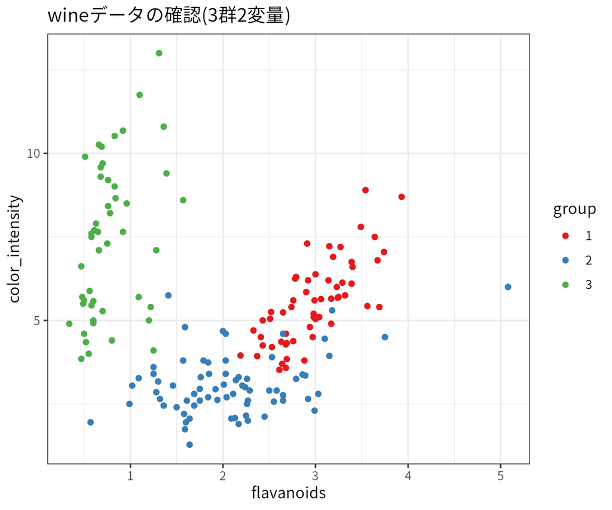

```r
# 散布図
ggplot(wine, aes(x = flavanoids, y = color_intensity, colour = factor(class))) +
    geom_point() +
    scale_colour_brewer(palette = "Set1") +
    labs(title = "wineデータの確認(3群2変量)", color = "group")
```

- 群別のサンプル数（3群178件）

```r
# 群別のサンプル数
addmargins(table(wine$class))
```

```
##
##   1   2   3 Sum
##  59  71  48 178
```

- データ全体の相関

```r
# データ全体の相関
cor(wine[, 2:3]) |> round(3)
```

```
##                 flavanoids color_intensity
## flavanoids           1.000          -0.172
## color_intensity     -0.172           1.000
```

- 群別の相関

```r
# 群別の相関
lapply(split(wine[, 2:3], wine[, "class"]),
       function(x) cor(x) |> round(3))
```

```
## $`1`
##                 flavanoids color_intensity
## flavanoids           1.000           0.742
## color_intensity      0.742           1.000
##
## $`2`
##                 flavanoids color_intensity
## flavanoids           1.000           0.379
## color_intensity      0.379           1.000
##
## $`3`
##                 flavanoids color_intensity
## flavanoids           1.000           0.367
## color_intensity      0.367           1.000
```

- データを訓練データとテストデータに分割  
  群別に指定した訓練データ比率のランダムサンプリングを行う（関数）

```r
train_test_split <- function(data, class_name = NA, train_perc = .5, seed = NA) {
    # 多群データをグループ毎に指定の訓練データ比率で分割する
    #
    # data:データフレーム形式,グループカラム含む
    # class_name:グループカラム名を指定
    # train_perc:訓練データ比率
    stopifnot(!is.na(class_name))

    data <- data[complete.cases(data), ] # 欠損データ除外
    data_split <- split(data, data[class_name]) # グループ別に分割
    n_list <- lapply(data_split, nrow) # グループ別のn数

    # グループ別に訓練データ比率に従ってサンプリング
    if(!is.na(seed)) set.seed(seed)
    samp_res <- lapply(seq_along(data_split), function(i) {
        seq_len(n_list[[i]]) %in% sample(seq_len(n_list[[i]]), n_list[[i]]*train_perc)
    })
    train_vec <- unlist(samp_res) # training data == TRUE

    # train/testデータ
    return(
        list(train = data[train_vec,],
             test = data[!train_vec,],
             train_perc = train_perc,
             seed = seed)
        )

}

train_test <- train_test_split(wine, class_name = "class", train_perc = .5, seed = 380)
wine_train <- train_test$train
wine_test <- train_test$test
```

- 訓練データの群別件数

```r
addmargins(table(wine_train$class))
```

```
##
##   1   2   3 Sum
##  29  35  24  88
```

- 訓練データの基本統計量

```r
print(skim(wine_train))
```

```
## ── Data Summary ────────────────────────
##                            Values
## Name                       wine_train
## Number of rows             88
## Number of columns          3
## _______________________
## Column type frequency:
##   numeric                  3
## ________________________
## Group variables            None
##
## ── Variable type: numeric ──────────────────────────────────────────────────────
##   skim_variable   n_missing complete_rate mean    sd   p0  p25  p50  p75  p100
## 1 class                   0             1 1.94 0.778 1    1    2    3     3
## 2 flavanoids              0             1 2.03 1.03  0.34 1.22 2.14 2.87  5.08
## 3 color_intensity         0             1 5.09 2.28  1.9  3.26 4.85 6.15 11.8
##   hist
## 1 ▆▁▇▁▆
## 2 ▆▅▇▂▁
## 3 ▇▇▃▂▁
```

- テストデータの群別件数

```r
addmargins(table(wine_test$class))
```

```
##
##   1   2   3 Sum
##  30  36  24  90
```

- テストデータの基本統計量  
  群別のサンプル数はほぼ同じ  
  `flavanoids`の分布がちょっと違う？

```r
print(skim(wine_test))
```

```
## ── Data Summary ────────────────────────
##                            Values
## Name                       wine_test
## Number of rows             90
## Number of columns          3
## _______________________
## Column type frequency:
##   numeric                  3
## ________________________
## Group variables            None
##
## ── Variable type: numeric ──────────────────────────────────────────────────────
##   skim_variable   n_missing complete_rate mean    sd   p0  p25  p50  p75  p100
## 1 class                   0             1 1.93 0.776 1    1    2    3     3
## 2 flavanoids              0             1 2.03 0.969 0.48 1.13 2.13 2.86  3.67
## 3 color_intensity         0             1 5.02 2.37  1.28 3.09 4.6  6.24 13
##   hist
## 1 ▇▁▇▁▅
## 2 ▇▅▅▇▅
## 3 ▇▇▃▂▁
```

- 訓練データとテストデータの確認  
  ランダムスプリットの結果  
  サンプル数少ないので厳しい？

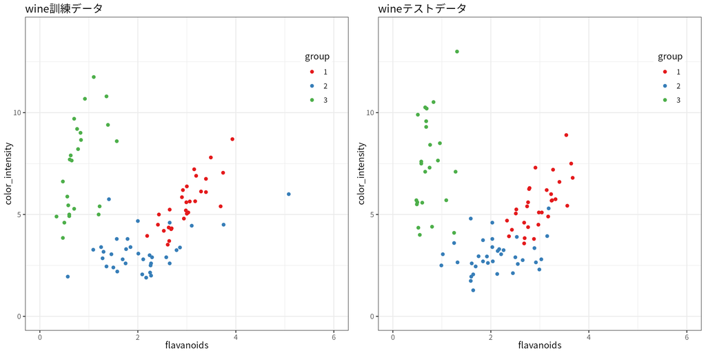

```r
# 可視化
p_train <- ggplot(wine_train, aes(x = flavanoids, y = color_intensity, colour = factor(class))) +
    geom_point() +
    scale_colour_brewer(palette = "Set1") +
    labs(title = "wine訓練データ", color = "group") +
    xlim(0, 6) + ylim(0, 14) +
    theme(legend.position = c(.9, .8))
p_test <- ggplot(wine_test, aes(x = flavanoids, y = color_intensity, colour = factor(class))) +
    geom_point() +
    scale_colour_brewer(palette = "Set1") +
    labs(title = "wineテストデータ", color = "group") +
    xlim(0, 6) + ylim(0, 14) +
    theme(legend.position = c(.9, .8))

plot_grid(p_train, p_test, label_size = 12, ncol = 2)
```

- 訓練データを使って多群対応のLDAを実行  
  3群以上のデータに対応する線形判別分析

```r
# 多群対応のLDA
mclass_LDA <- function(data, class_name) {
    # data: classを含む分析対象データ
    # class_name: data内のclassに相当する項目名
    data <- data[complete.cases(data), ] # 欠損データ除外
    X <- data[, !colnames(data) %in% class_name] # 説明変数行列

    # 統計量
    g <- length(unique(data[[class_name]])) # 群の数
    pi_k_vec <- as.data.frame(table(data[[class_name]]))[, 2]/length(data[[class_name]]) # 事前確率
    n <- nrow(data)-g # 全体サンプル数
    mclass_data <- split(X, data[[class_name]]) # 群別データ
    mclass_n <- lapply(mclass_data, function(x) nrow(x)-1) # 群別サンプル数
    mclass_mu <- lapply(mclass_data, function(x) colMeans(x)) # 群別平均ベクトル
    mclass_data_cent <- lapply(seq_along(mclass_data), # 平均偏差データ
                                  function(i) sweep(mclass_data[[i]], 2, mclass_mu[[i]]))
    mclass_S <- lapply(mclass_data_cent, function(x) cov(x)) # 群別分散共分散行列
    wgt_S <- Reduce("+", lapply(1:g, function(i) mclass_S[[i]]*mclass_n[[i]]))/n # 重み付きS
    Sinv <- solve(wgt_S) # 共通S^-1

    # 判別関数の計算
    X <- data.matrix(X)
    score_mat <- matrix(NA, nrow = nrow(X), ncol = g) # scoring結果格納用
    ## 群の数に応じて判別境界を計算
    for (i in seq_len(g-1)) {
        a <- (mclass_mu[[i]] + mclass_mu[[g]])/2
        b <- Sinv %*% (mclass_mu[[i]] - mclass_mu[[g]])
        score_mat[, i] <- apply(X, 1, function(x) t(x)%*%b - t(a)%*%b + log(pi_k_vec[[i]]/pi_k_vec[[g]]))
    }
    score_mat[, g] <- 0 # ベースラインクラスのスコア==0
    class_vec <- apply(score_mat, 1, which.max) # 判別クラスの決定

    # 結果の格納
    return(list(score_mat = score_mat,
                class_vec = as.vector(class_vec),
                g = g,
                Sinv = Sinv,
                class_mu = mclass_mu,
                pi_k_vec = pi_k_vec))

}
# LDAの実行
res_LDA <- mclass_LDA(wine_train, "class")
```

- LDA判別結果

```r
# 判別結果
table(wine_train[, "class"], res_LDA$class_vec)
```

```
##
##      1  2  3
##   1 23  6  0
##   2  4 30  1
##   3  0  0 24
```

- LDA判別精度

```r
cnt_tbl <- as.data.frame.matrix(table(wine_train[, "class"], res_LDA$class_vec))

# 誤判別確率
lda_train_err <- mean(wine_train[, "class"] != res_LDA$class_vec) |> round(3)
lda_train_err
```

```
## [1] 0.125
```

- テストデータを使って汎化性能を確認  
  mclass_LDA関数用の予測用関数

```r
# LDAによる予測
predict_mclass_LDA <- function(result, data) {
    # result:mclass_LDA関数の結果object
    # data:説明変数行列（class は含まない）

    # resultからの群別統計量
    g <- result$g
    Sinv <- result$Sinv
    class_mu <- result$class_mu
    pi_k_vec <- result$pi_k_vec

    stopifnot(ncol(Sinv) == ncol(data))
    # 判別関数の計算
    X <- data.matrix(data)
    score_mat <- matrix(NA, nrow = nrow(X), ncol = g) # scoring結果格納用
    ## 群の数に応じて判別境界を計算
    for (i in seq_len(g-1)) {
        a <- (class_mu[[i]] + class_mu[[g]])/2
        b <- Sinv %*% (class_mu[[i]] - class_mu[[g]])
        score_mat[, i] <- apply(X, 1, function(x) t(x)%*%b - t(a)%*%b + log(pi_k_vec[[i]]/pi_k_vec[[g]]))
    }
    score_mat[, g] <- 0 # ベースラインクラスのスコア==0
    class_vec <- apply(score_mat, 1, which.max) # 判別クラスの決定
    # 結果の格納
    return(list(score_mat = score_mat,
                class_vec = as.vector(class_vec)))
}
# テストデータにLDA実行
pred_LDA <- predict_mclass_LDA(res_LDA, wine_test[, -1])
```

- テストデータへのLDA判別結果

```r
# 判別結果
table(wine_test[, "class"], pred_LDA$class_vec)
```

```
##
##      1  2  3
##   1 25  5  0
##   2  2 34  0
##   3  0  1 23
```

- テストデータへのLDA判別精度

```r
cnt_tbl <- as.data.frame.matrix(table(wine_test[, "class"], pred_LDA$class_vec))

# 誤判別確率
lda_test_err <- mean(wine_test[, "class"] != pred_LDA$class_vec) |> round(3)
lda_test_err
```

```
## [1] 0.089
```

- 訓練/テストデータへのLDA判別結果の確認

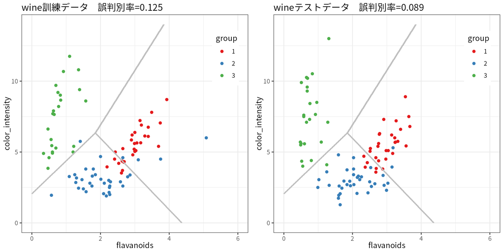

```r
# scoring grid
xp <- seq(0, 6, length.out = 300)
yp <- seq(0, 14, length.out = 700)
grid_plot <- expand.grid(X1 = xp, X2 = yp)

# predict LDA
grid_plot$lda_score <- predict_mclass_LDA(res_LDA, grid_plot[, 1:2])$class

# 可視化
p_train_lda <- ggplot() +
    geom_point(data = wine_train, aes(flavanoids, color_intensity, color = factor(class))) +
    # labs(title = "LDAによる判別境界", color = "group") +
    scale_colour_brewer(palette = "Set1") +
    labs(title = paste0("wine訓練データ　", "誤判別率=", lda_train_err), color = "group") +
    xlim(0, 6) + ylim(0, 14) +
    theme(legend.position = c(.9, .8)) +
    geom_contour(data = grid_plot, aes(X1, X2, z = lda_score), col = "gray")

p_test_lda <- ggplot() +
    geom_point(data = wine_test, aes(flavanoids, color_intensity, color = factor(class))) +
    # labs(title = "LDAによる判別境界", color = "group") +
    scale_colour_brewer(palette = "Set1") +
    labs(title = paste0("wineテストデータ　", "誤判別率=", lda_test_err), color = "group") +
    xlim(0, 6) + ylim(0, 14) +
    theme(legend.position = c(.9, .8)) +
    geom_contour(data = grid_plot, aes(X1, X2, z = lda_score), col = "gray")

plot_grid(p_train_lda, p_test_lda, label_size = 12, ncol = 2)
```

### 3群のQDAの実行

教科書p82の事例を行う（codeは適宜書き直した）

- 訓練データを使って多群対応のQDAを実行  
  3群以上のデータに対応する2次判別分析

```r
# 多群対応のQDA
mclass_QDA <- function(data, class_name) {
    # data: classを含む分析対象データ
    # class_name: data内のclassに相当する項目名
    data <- data[complete.cases(data), ] # 欠損データ除外
    X <- data[, !colnames(data) %in% class_name] # 説明変数行列

    # 群別統計量
    g <- length(unique(data[[class_name]])) # 群の数
    pi_k_vec <- as.data.frame(table(data[[class_name]]))[, 2]/length(data[[class_name]]) # 事前確率

    mclass_data <- split(X, data[[class_name]]) # 群別データ
    mclass_mu <- lapply(mclass_data, function(x) colMeans(x)) # 群別平均ベクトル
    mclass_data_cent <- lapply(seq_along(mclass_data), # 平均偏差データ
                                  function(i) sweep(mclass_data[[i]], 2, mclass_mu[[i]]))
    mclass_Sinv <- lapply(mclass_data_cent, function(x) solve(cov(x))) # 群別S^-1
    mclass_det <- lapply(mclass_data_cent, function(x) det(cov(x))) # 群別det

    # 判別関数の計算
    X <- data.matrix(X)
    score_mat <- matrix(NA, nrow = nrow(X), ncol = g) # scoring結果格納用
    ## 群の数に応じて判別境界を計算
    for (i in seq_len(g-1)) {
        d_1 <- rowSums(sweep(X, 2, mclass_mu[[i]]) %*% mclass_Sinv[[i]] * sweep(X, 2, mclass_mu[[i]]))
        d_2 <- rowSums(sweep(X, 2, mclass_mu[[g]]) %*% mclass_Sinv[[g]] * sweep(X, 2, mclass_mu[[g]]))
        diff_d <- d_2-d_1
        score_mat[, i] <- log(sqrt(mclass_det[[g]]/mclass_det[[i]])) + (diff_d)/2 + log(pi_k_vec[[i]]/pi_k_vec[[g]])
    }
    score_mat[, g] <- 0 # ベースラインクラスのスコア==0
    class_vec <- apply(score_mat, 1, which.max) # 判別クラスの決定

    # 結果の格納
    return(list(score_mat = score_mat,
                class_vec = as.vector(class_vec),
                class_mu = mclass_mu,
                class_Sinv = mclass_Sinv,
                class_det = mclass_det,
                g = g,
                pi_k_vec = pi_k_vec))
}

# QDAの実行
res_QDA <- mclass_QDA(wine_train, "class")
```

- QDA判別結果

```r
# 判別結果
table(wine_train[, "class"], res_QDA$class_vec)
```

```
##
##      1  2  3
##   1 25  4  0
##   2  1 33  1
##   3  0  0 24
```

- QDA判別精度

```r
cnt_tbl <- as.data.frame.matrix(table(wine_train[, "class"], res_QDA$class_vec))

# 誤判別確率
qda_train_err <- mean(wine_train[, "class"] != res_QDA$class_vec) |> round(3)
qda_train_err
```

```
## [1] 0.068
```

- テストデータを使って汎化性能を確認  
  mclass_QDA関数用の予測用関数

```r
# QDAによる予測
predict_mclass_QDA <- function(result, data) {
    # result:mclass_QDA関数の結果object
    # data:説明変数行列（class は含まない）

    # resultからの群別統計量
    g <- result$g
    class_Sinv <- result$class_Sinv
    class_mu <- result$class_mu
    class_det <- result$class_det
    pi_k_vec <- result$pi_k_vec

    stopifnot( all(sapply(class_Sinv, function(i) ncol(i) == ncol(data))) )
    # 判別関数の計算
    X <- data.matrix(data)
    score_mat <- matrix(NA, nrow = nrow(X), ncol = g) # scoring結果格納用
     for (i in seq_len(g-1)) {
        d_1 <- rowSums(sweep(X, 2, class_mu[[i]]) %*% class_Sinv[[i]] * sweep(X, 2, class_mu[[i]]))
        d_2 <- rowSums(sweep(X, 2, class_mu[[g]]) %*% class_Sinv[[g]] * sweep(X, 2, class_mu[[g]]))
        diff_d <- d_2-d_1
        score_mat[, i] <- log(sqrt(class_det[[g]]/class_det[[i]])) + (diff_d)/2 + log(pi_k_vec[[i]]/pi_k_vec[[g]])
    }
    score_mat[, g] <- 0 # ベースラインクラスのスコア==0
    class_vec <- apply(score_mat, 1, which.max) # 判別クラスの決定
    # 結果の格納
    return(list(score_mat = score_mat,
                class_vec = as.vector(class_vec)))
}
# テストデータにQDA実行
pred_QDA <- predict_mclass_QDA(res_QDA, wine_test[, -1])
```

- QDA判別結果

```r
# 判別結果
table(wine_test[, "class"], pred_QDA$class)
```

```
##
##      1  2  3
##   1 26  4  0
##   2  2 34  0
##   3  0  1 23
```

- QDA判別精度

```r
cnt_tbl <- as.data.frame.matrix(table(wine_test[, "class"], pred_QDA$class))
# 誤判別確率
qda_test_err <- mean(wine_test[, "class"] != pred_QDA$class_vec) |> round(3)
qda_test_err
```

```
## [1] 0.078
```

- 訓練/テストデータへのQDA判別結果の確認  
  判別境界は曲線となる  
  誤判別率は訓練/テストデータともにLDAに比べて低下

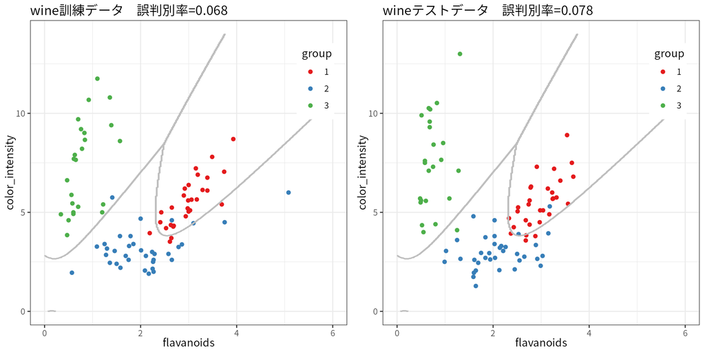

```r
# predict QDA
grid_plot$qda_score <- predict_mclass_QDA(res_QDA, grid_plot[, 1:2])$class

# 可視化
p_train_qda <- ggplot() +
    geom_point(data = wine_train, aes(flavanoids, color_intensity, color = factor(class))) +
    # labs(title = "LDAによる判別境界", color = "group") +
    scale_colour_brewer(palette = "Set1") +
    labs(title = paste0("wine訓練データ　", "誤判別率=", qda_train_err), color = "group") +
    xlim(0, 6) + ylim(0, 14) +
    theme(legend.position = c(.9, .8)) +
    geom_contour(data = grid_plot, aes(X1, X2, z = qda_score), col = "gray")

p_test_qda <- ggplot() +
    geom_point(data = wine_test, aes(flavanoids, color_intensity, color = factor(class))) +
    # labs(title = "LDAによる判別境界", color = "group") +
    scale_colour_brewer(palette = "Set1") +
    labs(title = paste0("wineテストデータ　", "誤判別率=", qda_test_err), color = "group") +
    xlim(0, 6) + ylim(0, 14) +
    theme(legend.position = c(.9, .8)) +
    geom_contour(data = grid_plot, aes(X1, X2, z = qda_score), col = "gray")

plot_grid(p_train_qda, p_test_qda, label_size = 12, ncol = 2)
```

### 結果の比較（訓練/テストデータの誤判別率）

- 誤判別率  
  LDAよりもQDAの誤判別率が低い  
  一般的に訓練データの誤判別率は低く、テストデータで悪化する  
  LDAはテストデータの誤判別率が訓練データより良くなった  
  QDAも誤判別の件数だけ見れば1件しか違わない（6件→7件）  
  精度をみるにはサンプルが少なすぎるかもしれない

```r
# LDA/QDA 誤判別率
data.frame(train = c(lda_train_err, qda_train_err),
           test = c(lda_test_err, qda_test_err),
           row.names = c("LDA", "QDA"))
```

|  | train | test |
| --- | --- | --- |
| LDA | 0.125 | 0.089 |
| QDA | 0.068 | 0.078 |

### 多変量データへの適用（参考）

- Wine全データへの適用  
  上記検証では2変数（フラボノイド含有量, 色強度）のみで3群の判別を行った  
  元データの持つ全変数（14変数）を使った場合の検証を行う
- Wine全変数を使ったLDA

```r
# 訓練データとテストデータ分割
train_test_Wine <- train_test_split(Wine, "class", train_perc = .5, seed = 123)

# LDAによる判別分析（Wineデータ全変数）
## 訓練データによるモデルフィット
res_LDA_Wine <- mclass_LDA(train_test_Wine$train, "class")
## 訓練データのフィッティング
table(train_test_Wine$train[["class"]], res_LDA_Wine$class_vec)
```

```
##
##      1  2  3
##   1 29  0  0
##   2  0 35  0
##   3  0  0 24
```

```r
lda_train_err2 <- mean(train_test_Wine$train[["class"]] != res_LDA_Wine$class_vec) |> round(3)
```

- LDAのテストデータへの適用

```r
## テストデータによる予測
pred_LDA_Wine <- predict_mclass_LDA(res_LDA_Wine, train_test_Wine$test[, -1])
## テストデーによる予測結果
table(train_test_Wine$test[, "class"], pred_LDA_Wine$class_vec)
```

```
##
##      1  2  3
##   1 30  0  0
##   2  1 33  2
##   3  0  0 24
```

```r
lda_test_err2 <- mean(train_test_Wine$test[, "class"] != pred_LDA_Wine$class_vec) |> round(3)
```

- Wine全変数を使ったQDA

```r
# QDAによる判別分析（Wineデータ全変数）
## 訓練データによるモデルフィット
res_QDA_Wine <- mclass_QDA(train_test_Wine$train, "class")
## 訓練データのフィッティング
table(train_test_Wine$train[["class"]], res_QDA_Wine$class_vec)
```

```
##
##      1  2  3
##   1 29  0  0
##   2  0 35  0
##   3  0  0 24
```

```r
qda_train_err2 <- mean(train_test_Wine$train[["class"]] != res_QDA_Wine$class_vec) |> round(3)
```

- QDAのテストデータへの適用

```r
## テストデータによる予測
pred_QDA_Wine <- predict_mclass_QDA(res_QDA_Wine, train_test_Wine$test[, -1])
## テストデーによる予測結果
table(train_test_Wine$test[, "class"], pred_QDA_Wine$class_vec)
```

```
##
##      1  2  3
##   1 30  0  0
##   2  0 36  0
##   3  0  1 23
```

```r
qda_test_err2 <- mean(train_test_Wine$test[, "class"] != pred_QDA_Wine$class_vec) |> round(3)
```

- 誤判別率  
  多変数にしてもLDAよりもQDAの誤判別率が低い  
  訓練データは誤判別率0％  
  テストデータの誤判別も極めて少ない  
  サンプル数や群の数がより多い、判別の難しいデータで他の手法と比較して特性を確認した方が良いかも

```r
# LDA/QDA 誤判別率
data.frame(train = c(lda_train_err2, qda_train_err2),
           test = c(lda_test_err2, qda_test_err2),
           row.names = c("LDA", "QDA"))
```

|  | train | test |
| --- | --- | --- |
| LDA | 0 | 0.033 |
| QDA | 0 | 0.011 |

### 2.1章～2.3章へ戻る

2.1章~2.3章 2群の場合のベイズ判別法